# 3.modelling (exercises)

Joao Lopes

2026-03-25

# 1. BUILD A MODEL

```r
library("dotwhisker")
library("tidymodels")
library("tidyverse")
library("janitor")
```

## 1.1. LOOK AT DATA

[no exercises]

## 1.2. FIT A MODEL

a) Evaluate the following model using function glance(). Evaluate it also using function augment() and rsq() from tidymodels. What are the possible problems of using the same data to fit and to evaluate the model?

```r
set.seed(123)
lev_cut = c("Fair", "Good", "Very Good", "Premium", "Ideal")
diamond_data <- diamonds |>
  mutate(
    log_price = log(price),
    log_carat = log(carat),
    cut = fct(as.character(cut), levels = lev_cut),
    .keep = "used"
  ) |>
  slice_sample(n = 1000)

diamond_fit <- linear_reg() |>
  fit(log_price ~ log_carat + cut, data = diamond_data)
```

```r
#loading data and making changes
set.seed(123)
lev_cut = c("Fair", "Good", "Very Good", "Premium", "Ideal")
diamond_data <- diamonds |>
  mutate(
    log_price = log(price),
    log_carat = log(carat),
    cut = fct(as.character(cut), levels = lev_cut),
    .keep = "used"
  ) |>
  slice_sample(n = 1000)

#fit model
diamond_fit <- linear_reg() |>
  fit(log_price ~ log_carat + cut, data = diamond_data)

#evaluate using glance()
glance(diamond_fit)
```

```
## # A tibble: 1 × 12
##   r.squared adj.r.squared sigma statistic p.value    df logLik   AIC   BIC
##       <dbl>         <dbl> <dbl>     <dbl>   <dbl> <dbl>  <dbl> <dbl> <dbl>
## 1     0.943         0.943 0.243     3279.       0     5 0.0720  13.9  48.2
## # ℹ 3 more variables: deviance <dbl>, df.residual <int>, nobs <int>
```

```r
#evaluate using augment() and rsq()
augment(diamond_fit, new_data = diamond_data) |>
  rsq(truth = log_price, estimate = .pred)
```

```
## # A tibble: 1 × 3
##   .metric .estimator .estimate
##   <chr>   <chr>          <dbl>
## 1 rsq     standard       0.943
```

```r
# Conclusions
# 1. Using same data to fit and evaluate can overestimate evaluation.
```

b) How can you avoid overestimating the evaluation of the model? Consider taking a new sample of the data.

```r
#obtain a new sample of the data
set.seed(456)
diamond_data2 <- diamonds |>
  mutate(
    log_price = log(price),
    log_carat = log(carat),
    cut = fct(as.character(cut), levels = lev_cut),
    .keep = "used"
  ) |>
  slice_sample(n = 1000)

#evaluate using the new sample
augment(diamond_fit, new_data = diamond_data2) |>
  rsq(truth = log_price, estimate = .pred)
```

```
## # A tibble: 1 × 3
##   .metric .estimator .estimate
##   <chr>   <chr>          <dbl>
## 1 rsq     standard       0.938
```

c) Using the same fitted model, build by hand a plot showing how the residuals vary a long the values of the predictors.

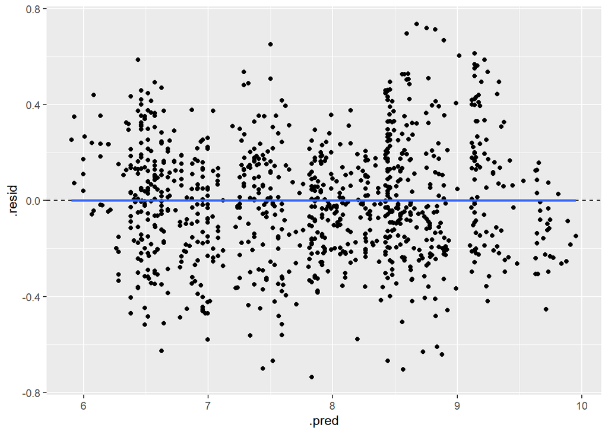

```r
#plot residuals ~ fitted
augment(diamond_fit, new_data = diamond_data) |>
  ggplot(aes(y = .resid, x = .pred)) +
  geom_point() +
  geom_hline(yintercept = 0, linetype = "dashed") +
  stat_smooth(method = "lm", formula = "y ~ x", se = FALSE)
```

## 1.3. USE MODEL TO PREDICT

a) Using the model from the previous section, predict the price of diamonds with 1, 2 and 3 carat for cuts “Fair”, “Very Good” and “Ideal”. Build a plot of the predictions using a confidence interval of 90%.

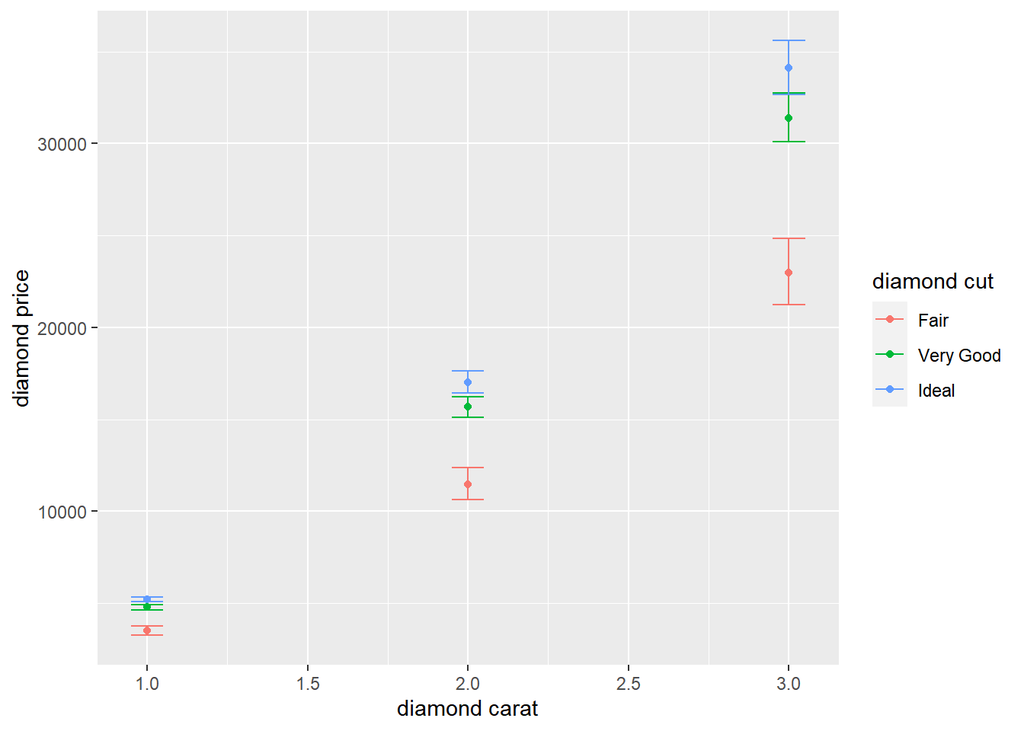

```r
#create new points
new_points2 <- expand.grid(
  log_carat = log(1:3),  cut = c("Fair", "Very Good", "Ideal"))

#create plot
k <- exp(glance(diamond_fit)$sigma^2/2) #unbiased constant for log-transf
bind_cols(
  #new points
  new_points2,
  #fitted values
  predict(diamond_fit, new_data = new_points2),
  #confidence intervals
  predict(diamond_fit, new_data = new_points2, type = "conf_int", level = 0.90)
) |>
  #plot data
  ggplot(aes(x = exp(log_carat), color = cut)) +
  geom_point(aes(y = k*exp(.pred))) +
  geom_errorbar(
    aes(ymin = k*exp(.pred_lower), ymax = k*exp(.pred_upper)),
    width = 0.1
  ) +
  labs(x = "diamond carat", y = "diamond price", color = "diamond cut")
```

# 2. BUILD A MODEL USING WORKFLOW

```r
library("nycflights13")
library("tidymodels")
library("tidyverse")
library("themis")
```

## 2.1. LOOK AT DATA

[no exercises]

## 2.2. SPLIT DATA

[no exercises]

## 2.3. CREATE MODEL

[no exercises]

## 2.4. CREATE RECIPE

[no exercises]

## 2.5. CREATE WORKFLOW

a) Considering the following workflow, build a new workflow without the steps of the recipe. Consider replacing the function add_recipe() with add_formula().

```r
flight_mod <- logistic_reg() |>
  set_engine("glm")

flight_rec <-
  recipe(arr_delay ~ ., data = train_data) |>
  step_date(date, features = c("dow", "month")) |>
  step_holiday(date, holidays = timeDate::listHolidays("US")) |>
  step_rm(date) |>
  step_dummy(all_nominal_predictors()) |>
  step_zv(all_predictors()) |>
  step_corr(all_numeric_predictors(), threshold = 0.9) |>
  step_normalize(all_numeric_predictors())

flight_wflow <-
  workflow() |>
  add_model(flight_mod) |>
  add_recipe(flight_rec)
```

```r
#create model specification
flight_mod <- logistic_reg() |>
  set_engine("glm")

#create workflow
flight_wflow2 <-
  workflow() |>
  add_model(flight_mod) |>
  add_formula(arr_delay ~ .)
```

## 2.6. FIT A MODEL

a) Using the given workflow and the newly created one, fit the two models to the following data set. Consider the data split in train and test sets.

```r
set.seed(123)
flight_data <-
  flights |>
  mutate(
    arr_delay = if_else(arr_delay >= 30, "late", "on_time"),
    arr_delay = fct(arr_delay, levels = c("late", "on_time")),
    date = lubridate::as_date(time_hour)
  ) |>
  select(dep_time, origin, dest, distance, carrier, date, arr_delay) |>
  drop_na() |>
  mutate(across(where(is.character), as.factor)) |>
  slice_sample(n = 10000)

set.seed(456)
data_split <- initial_split(flight_data, prop = 3/4)
flight_train <- training(data_split)
flight_test  <- testing(data_split)
```

```r
#loading data and making changes
set.seed(123)
flight_data <-
  flights |>
  mutate(
    arr_delay = if_else(arr_delay >= 30, "late", "on_time"),
    arr_delay = fct(arr_delay, levels = c("late", "on_time")),
    date = lubridate::as_date(time_hour)
  ) |>
  select(dep_time, origin, dest, distance, carrier, date, arr_delay) |>
  drop_na() |>
  mutate(across(where(is.character), as.factor)) |>
  slice_sample(n = 10000)

#create random data split
set.seed(456)
data_split <- initial_split(flight_data, prop = 3/4)
flight_train <- training(data_split)
flight_test  <- testing(data_split)

#create model specification
flight_mod <- logistic_reg() |>
  set_engine("glm")

#create recipe
flight_rec <-
  recipe(arr_delay ~ ., data = flight_train) |>
  step_date(date, features = c("dow", "month")) |>
  step_holiday(date, holidays = timeDate::listHolidays("US")) |>
  step_rm(date) |>
  step_dummy(all_nominal_predictors()) |>
  step_zv(all_predictors()) |>
  step_corr(all_numeric_predictors(), threshold = 0.9) |>
  step_normalize(all_numeric_predictors())

#create workflow 1
flight_wflow <-
  workflow() |>
  add_model(flight_mod) |>
  add_recipe(flight_rec)

#create workflow 2
flight_wflow2 <-
  workflow() |>
  add_model(flight_mod) |>
  add_formula(arr_delay ~ .)

#fit both models
flight_fit <- flight_wflow |> fit(data = flight_train)
flight_fit2 <- flight_wflow2 |>  fit(data = flight_train)
```

## 2.7. EVALUATE MODEL

a) How did the previously fitted models perform? Use the appropriate statistic.

```r
#evaluate both models
flight_aug <- augment(flight_fit, new_data = flight_test)
flight_aug |> roc_auc(truth = arr_delay, .pred_late)
```

```
## # A tibble: 1 × 3
##   .metric .estimator .estimate
##   <chr>   <chr>          <dbl>
## 1 roc_auc binary         0.693
```

```r
flight_aug2 <- augment(flight_fit2, new_data = flight_test)
flight_aug2 |> roc_auc(truth = arr_delay, .pred_late)
```

```
## # A tibble: 1 × 3
##   .metric .estimator .estimate
##   <chr>   <chr>          <dbl>
## 1 roc_auc binary         0.671
```

b) Looking at the augmented data set, try to guess which probability threshold was used for predicting the classes in .pred_class?

```r
flight_aug |>
  select(.pred_class, .pred_late) |>
  arrange(desc(.pred_late)) |>
  mutate(
    is_ontime = as.numeric(.pred_class == "on_time"),
    is_thresh = as.logical(is_ontime - lag(is_ontime))
  ) |>
  filter(is_thresh)
```

```
## # A tibble: 1 × 4
##   .pred_class .pred_late is_ontime is_thresh
##   <fct>            <dbl>     <dbl> <lgl>
## 1 on_time          0.500         1 TRUE
```

```r
# Conclusions:
# 1. The probability considered is the classic 50% threshold.
```

c) Using function conf_mat(), calculate a confusion matrix for the best model. Using function tabyl(), calculate by hand a confusion matrix to the best model.

```r
#calculate confusion matrix with function conf_mat()
flight_aug |>
  conf_mat(truth = arr_delay, estimate = .pred_class)
```

```
##           Truth
## Prediction late on_time
##    late      32      31
##    on_time  338    2099
```

```r
#calculate confusion matrix by hand
flight_aug |> tabyl(.pred_class, arr_delay) |>
  rename(Prediction = .pred_class)
```

```
##  Prediction late on_time
##        late   32      31
##     on_time  338    2099
```

d) Use probability thresholds of 0.40 and 0.60 to predict the classes of the best model. How does the threshold value impact on the confusion matrix?

```r
#decrease probability threshold to 0.40
flight_aug |>
  mutate(.pred_class = if_else(.pred_on_time > 0.40, "on_time", "late")) |>
  tabyl(.pred_class, arr_delay) |>
  rename(Prediction = .pred_class)
```

```
##  Prediction late on_time
##        late   11       9
##     on_time  359    2121
```

```r
# Conclusions 1
# 1. A lower threshold decreases true positives and increases true negatives.

#increase probability threshold to 0.60
flight_aug |>
  mutate(.pred_class = if_else(.pred_on_time > 0.60, "on_time", "late")) |>
  tabyl(.pred_class, arr_delay) |>
  rename(Prediction = .pred_class)
```

```
##  Prediction late on_time
##        late   71      79
##     on_time  299    2051
```

```r
# Conclusions 2:
# 2. A higher threshold increases true positives and decreases true negatives.
```

e) Using the original confusion matrix calculate the sensitivity (= TP/P) and the specificity (= TN/N).

```r
#calculate statistics of the confusion matrix
flight_cmat <- flight_aug |> conf_mat(truth = arr_delay, .pred_class)
summary(flight_cmat)
```

```
## # A tibble: 13 × 3
##    .metric              .estimator .estimate
##    <chr>                <chr>          <dbl>
##  1 accuracy             binary        0.852
##  2 kap                  binary        0.109
##  3 sens                 binary        0.0865
##  4 spec                 binary        0.985
##  5 ppv                  binary        0.508
##  6 npv                  binary        0.861
##  7 mcc                  binary        0.163
##  8 j_index              binary        0.0719
##  9 bal_accuracy         binary        0.536
## 10 detection_prevalence binary        0.0252
## 11 precision            binary        0.508
## 12 recall               binary        0.0865
## 13 f_meas               binary        0.148
```

```r
#calculate sensitivity (= TP/P)
isens <- flight_cmat$table[1,1]/sum(flight_cmat$table[,1])
isens
```

```
## [1] 0.08648649
```

```r
#calculate specificity (= TN/N)
ispec <- flight_cmat$table[2,2]/sum(flight_cmat$table[,2])
ispec
```

```
## [1] 0.985446
```

f) Create the ROC curve and place the calculated values of sensitivity and specificity on it. Use geom_hline(), geom_vline() and geom_point().

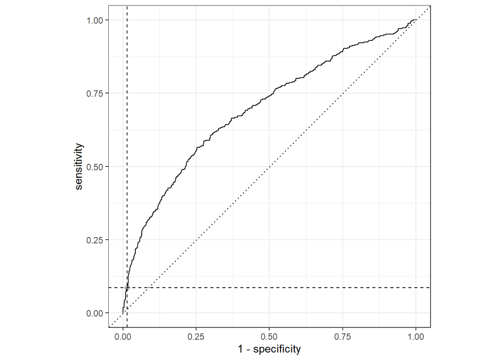

```r
#create ROC curve with sensitivity and specificity of the model
flight_aug |>
  roc_curve(truth = arr_delay, .pred_late) |>
  autoplot() +
  geom_vline(xintercept = 1 - ispec, lty = 2) +
  geom_hline(yintercept = isens, lty = 2) +
  geom_point(aes(x = 1 - ispec, y = isens), shape=21, size=2)
```

g) Find which terms are more important to the best fitted model and plot them. Use the statistics of each term as a proxy for their importance. Try also using the estimates of the coefficients. Are the results similar? Note that term “(Intercept)” is meaningless and should be discarded.

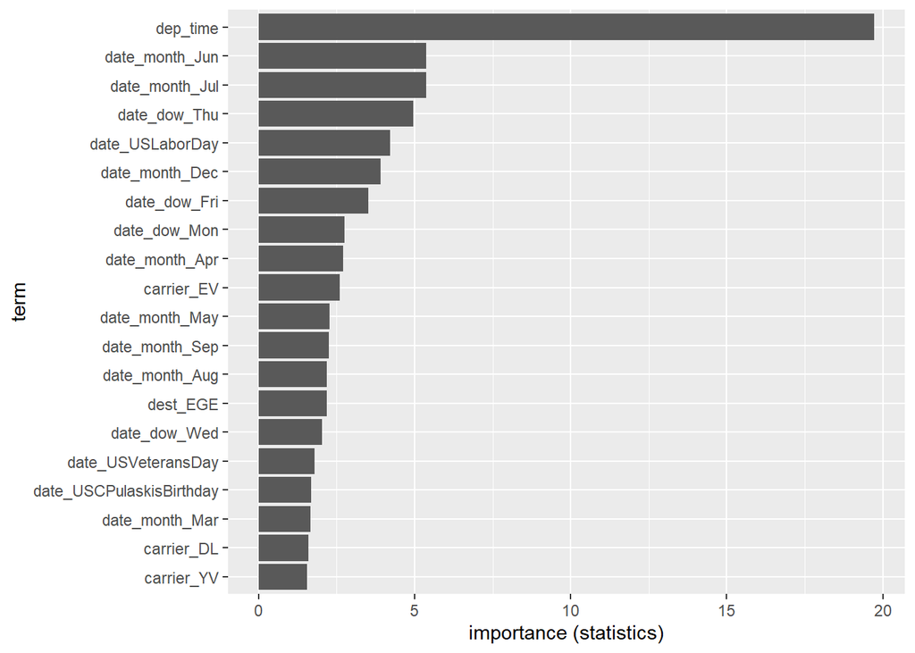

```r
#using importance = statistics
flight_fit |>
  tidy() |>
  filter(!term %in% c("(Intercept)")) |>
  mutate(
    importance = abs(statistic),
    term = fct_reorder(term, importance)
  ) |>
  arrange(desc(importance)) |>
  slice_head(n = 20) |>
  ggplot(aes(x = importance, y = term)) +
  geom_col() +
  labs(x = "importance (statistics)")
```

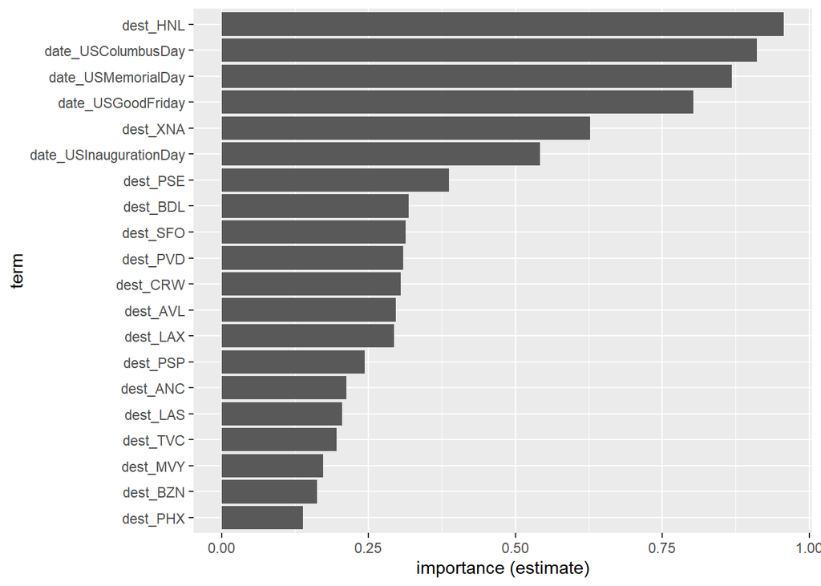

```r
# Conclusions 1:
# 1. dep_time is by far the most important term

#using importance = estimate
flight_fit |>
  tidy() |>
  filter(!term %in% c("(Intercept)")) |>
  mutate(
    importance = estimate,
    term = fct_reorder(term, importance)
  ) |>
  arrange(desc(importance)) |>
  slice_head(n = 20) |>
  ggplot(aes(x = importance, y = term)) +
  geom_col() +
  labs(x = "importance (estimate)")
```

```r
# Conclusions 2:
# 1. destinations are important terms
# 2. specific US holidays are also important

# Conclusions 3:
# 1. results are very different,
# 2. 'statistics' focus on the significance of the terms,
# 3. 'estimate' focus on the absolute value of the term.
```

# 3. BUILD VARIOUS MODELS USING WORKFLOW

```r
library("nnet")
library("NeuralNetTools")
library("vip")
library("tidymodels")
library("tidyverse")
library("themis")
```

## 3.1. LOOK AT DATA

[no exercises]

## 3.2. SPLIT DATA

[no exercises]

## 3.3. CREATE WORKFLOW AND FIT MODEL 1

a) Considering the following split data set and tidymodel recipe, create the respective workflow and fit a simple logistic model. Use a confusion matrix, a ROC curve and the ROC AUC to evaluate your model.

```r
hotels <-
  read_csv("https://tidymodels.org/start/case-study/hotels.csv") |>
  mutate(across(where(is.character), as.factor))

set.seed(123)
hotel_split <- initial_split(hotels, strata = children, prop = 0.75)
hotel_other <- training(hotel_split)
hotel_test  <- testing(hotel_split)

holidays <- c("AllSouls", "AshWednesday", "ChristmasEve", "Easter",
              "ChristmasDay", "GoodFriday", "NewYearsDay", "PalmSunday")
hotel_rec <-
  recipe(children ~ ., data = hotel_other) |>
  step_date(arrival_date) |>
  step_holiday(arrival_date, holidays = holidays) |>
  step_rm(arrival_date) |>
  step_downsample(children, skip=TRUE, seed=222) |>
  step_dummy(all_nominal_predictors()) |>
  step_zv(all_predictors()) |>
  step_corr(all_numeric_predictors(), threshold = 0.9) |>
  step_normalize(all_predictors())
```

```r
#loading data and making changes
hotels <-
  read_csv("https://tidymodels.org/start/case-study/hotels.csv") |>
  mutate(across(where(is.character), as.factor))
#create random data split
set.seed(123)
hotel_split <- initial_split(hotels, strata = children, prop = 0.75)
hotel_other <- training(hotel_split)
hotel_test  <- testing(hotel_split)

#create recipe
holidays <- c("AllSouls", "AshWednesday", "ChristmasEve", "Easter",
              "ChristmasDay", "GoodFriday", "NewYearsDay", "PalmSunday")
hotel_rec <-
  recipe(children ~ ., data = hotel_other) |>
  step_date(arrival_date) |>
  step_holiday(arrival_date, holidays = holidays) |>
  step_rm(arrival_date) |>
  step_downsample(children, skip=TRUE, seed=222) |>
  step_dummy(all_nominal_predictors()) |>
  step_zv(all_predictors()) |>
  step_corr(all_numeric_predictors(), threshold = 0.9) |>
  step_normalize(all_predictors())

#create model specification
glm_mod <-
  logistic_reg() |>
  set_engine("glm")

#create workflow
glm_wflow <-
  workflow() |>
  add_model(glm_mod) |>
  add_recipe(hotel_rec)

#fit model using training data
t1 <- Sys.time()
glm_res <-
  glm_wflow |>
  fit(data = hotel_other)
Sys.time() - t1
```

```
## Time difference of 4.574365 secs
```

```r
#calculate predictions using testing data
glm_aug <- augment(glm_res, new_data = hotel_test)

#evaluate best tuned model using confusion matrix
glm_aug |> conf_mat(truth = children, estimate = .pred_class)
```

```
##           Truth
## Prediction children none
##   children      760 2105
##   none          251 9384
```

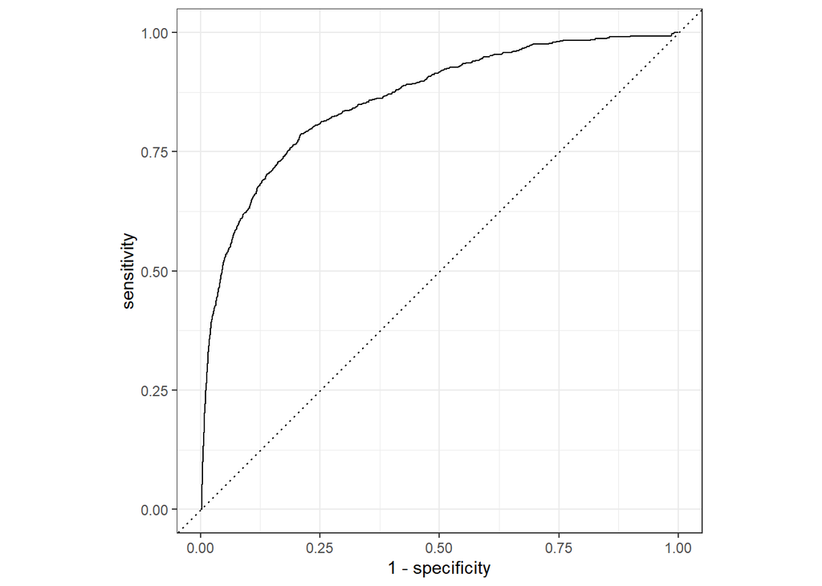

```r
#evaluate model using ROC curve
glm_aug |> roc_curve(children, .pred_children) |> autoplot()
```

```r
#evaluate model using ROC AUC
glm_aug |> roc_auc(truth = children, .pred_children)
```

```
## # A tibble: 1 × 3
##   .metric .estimator .estimate
##   <chr>   <chr>          <dbl>
## 1 roc_auc binary         0.859
```

## 3.4. CREATE WORKFLOW AND FIT MODEL 2

a) Replace the glm model used above with a neural network model. Consider function mlp() with engine “nnet” and mode “classification”. For the hyper parameters, set hidden_units = 2 and penalty = tune(). Use the same recipe as before. To tune the model set a grid of 10 points and use the given data split. Choose the best model and evaluate it with a confusion matrix, a ROC curve and the ROC AUC. How confident are you about the tuning?

```r
set.seed(234)
hotel_val <- validation_split(hotel_other, strata = children, prop = 0.80)
```

```r
#create random split of training data
set.seed(234)
hotel_val <- validation_split(hotel_other, strata = children, prop = 0.80)

#create model specification
cores <- parallel::detectCores()
nn_mod <-
  mlp(
    hidden_units = 2, #hidden units of the neural network
    penalty = tune(), #amount of regularization
  ) |>
  set_engine("nnet", num.threads = cores) |>
  set_mode("classification")

#create workflow
nn_wflow <-
  workflow() |>
  add_model(nn_mod) |>
  add_recipe(hotel_rec)

#fit model using training data and evaluate using tuning data
t1 <- Sys.time()
set.seed(345)
nn_res <-
  nn_wflow |>
  tune_grid(
    hotel_val,
    grid = 10,
    control = control_grid(save_pred = TRUE),
    metrics = metric_set(roc_auc)
  )
Sys.time() - t1
```

```
## Time difference of 40.80556 secs
```

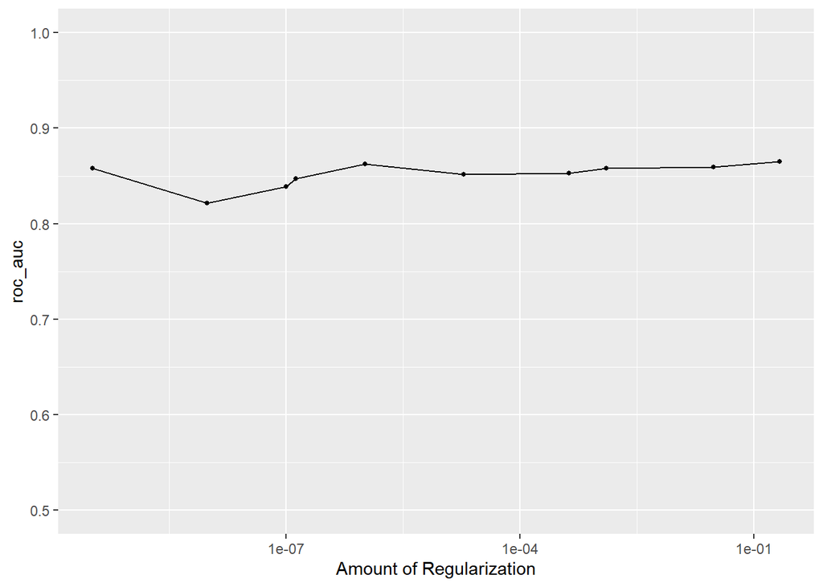

```r
#plot tuning metrics
autoplot(nn_res) + expand_limits(y=c(0.5, 1))
```

```r
# Conclusions 1
# 1. there is no clear best value of the parameter,
# 2. there is no clear trend for choosing best value.

#select best tuning parameter
nn_best <-
  nn_res |>
  select_best(metric = "roc_auc")

#collect predictions using best tuned model
nn_pred <-
  nn_res |>
  collect_predictions(parameters = nn_best)

#evaluate best tuned model using confusion matrix
nn_pred |>
  mutate(
    .pred_class = factor(if_else(.pred_children < 0.5, "none", "children"))
  ) |>
  conf_mat(truth = children, estimate = .pred_class)
```

```
##           Truth
## Prediction children none
##   children      455 1419
##   none          128 5498
```

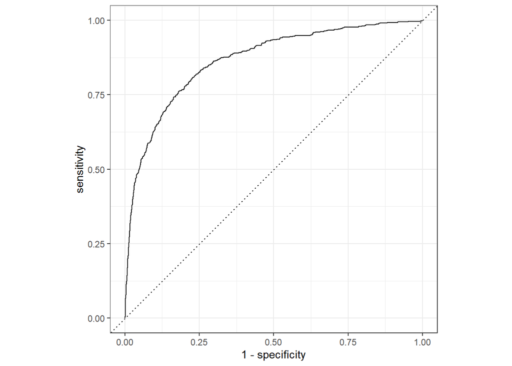

```r
#evaluate best tuned model using ROC curve
nn_pred |>
  roc_curve(children, .pred_children) |>
  autoplot()
```

```r
#evaluate best tuned model using ROC AUC
nn_pred |> roc_auc(children, .pred_children)
```

```
## # A tibble: 1 × 3
##   .metric .estimator .estimate
##   <chr>   <chr>          <dbl>
## 1 roc_auc binary         0.865
```

## 3.5. EVALUATE MODEL

a) Choose the best neural network model and evaluated it using the test data created before. For the evaluation, consider a confusion matrix, a ROC curve and the ROC AUC. Finish the analysis by plotting the most important features (i.e. predictors) of the final model.

```r
#build last model
last_nn_mod <-
  mlp(hidden_units = 2, penalty = nn_best$penalty) |>
  set_engine("nnet", num.threads = cores) |>
  set_mode("classification")

#create last workflow
last_nn_wflow <-
  nn_wflow |>
  update_model(last_nn_mod)

#fit last model using testing data
t1 <- Sys.time()
set.seed(345)
last_nn_fit <-
  last_nn_wflow |>
  last_fit(split = hotel_split)
Sys.time() - t1
```

```
## Time difference of 7.950012 secs
```

```r
#collect predictions using testing data
last_nn_pred <- last_nn_fit |>
  collect_predictions()

#evaluate last model using confusion matrix
last_nn_pred |>
  mutate(
    .pred_class = factor(if_else(.pred_children < 0.5, "none", "children"))
  ) |>
  conf_mat(truth = children, estimate = .pred_class)
```

```
##           Truth
## Prediction children none
##   children      795 2702
##   none          216 8787
```

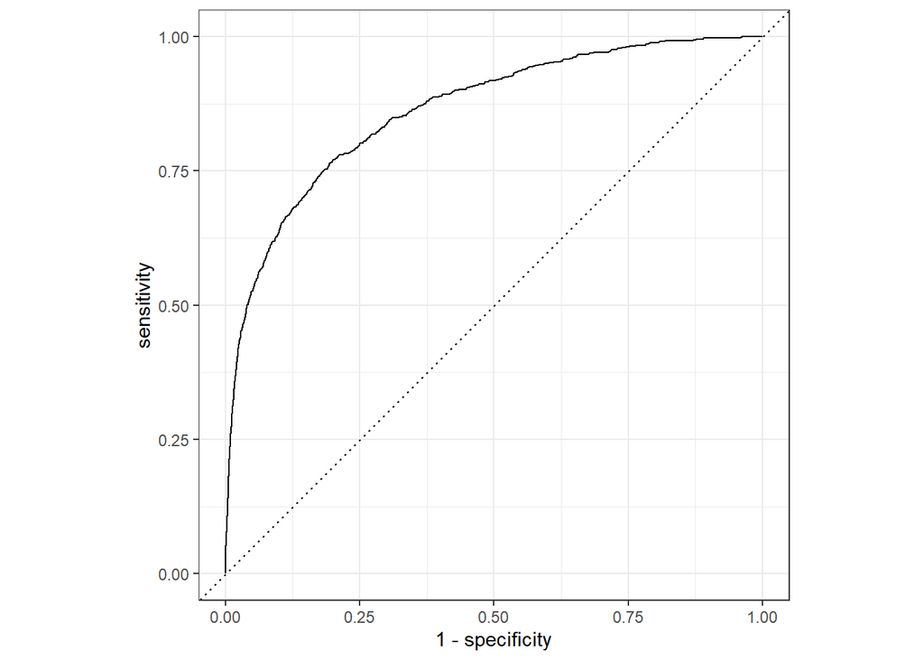

```r
#evaluate last model using ROC curve
last_nn_pred |>
  roc_curve(children, .pred_children) |>
  autoplot()
```

```r
#evaluate model using ROC AUC
last_nn_pred |>
  roc_auc(children, .pred_children)
```

```
## # A tibble: 1 × 3
##   .metric .estimator .estimate
##   <chr>   <chr>          <dbl>
## 1 roc_auc binary         0.863
```

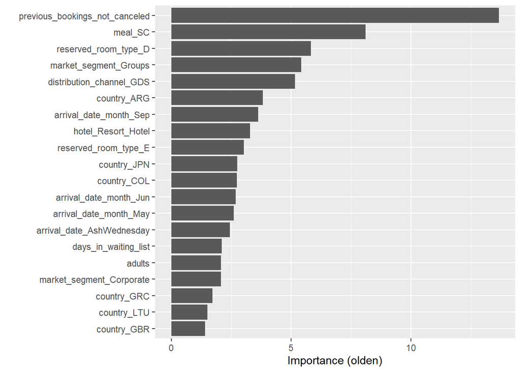

```r
#extract results
last_nn_fit |>
  extract_fit_parsnip() |>
  vip(num_features = 20, include_type=TRUE)
```